# De Silva_HW7

Sindupa De Silva

4/15/2021

Included in this homework is the same bobcat occupancy modeling dataset from homework 5:

*Bobcat.csv*: detection / non-detection of bobcat at each camera. Each row is a camera, and each column is a replicate survey (1 day).

*p covariates.csv*: number of people (divided by 100) photographed. Each row is a camera, and each column is a replicate survey (1 day). This is a detection covariate.

*psi covariates.csv*: the single covariate represents the proportion of area within 5km recently disturbed (e.g., logging, housing development). Treat this as a site-level covariate.

1. Load data and place into an unmarkedFrameOccu object

```r
library(unmarked)
library(AICcmodavg)
# Import data
Bobcats <- read.csv('Bobcat.csv') # detection/ non-detection
Cameras <- read.csv('p covariates.csv') # detection covariate
Disturbance <- read.csv('psi covariates.csv') # site-level covariate

# Create a list of site-level covariates
People <- list(People = Cameras)
#Disturbance <- list(Dist = data.frame(factor(Disturbance_1)))

# Place the data into an unmarkedFrameOccu object
Occu_data <- unmarkedFrameOccu(y = as.matrix(Bobcats), # detection / non-detection
                                 siteCovs = Disturbance, # site-level covariate
                                 obsCovs = People) # detection covariate
```

2. Fit the following candidate set of models:

```r
# Making a list of distinct candidate models

# Detection model = Intercept-only, Occupancy model = Intercept-only
Fit_1 <- occu(~ 1 ~ 1, data = Occu_data)

# Detection model = People, Occupancy model = Intercept-only
Fit_2 <- occu(~ People ~ 1, data = Occu_data)

# Detection model = Intercept-only, Occupancy model = disturbance
Fit_3 <- occu(~ 1 ~ Dist_5km, data = Occu_data)

# Detection model = People,  Occupancy model = disturbance
Fit_4 <- occu(~ People ~ Dist_5km, data = Occu_data)
```

3. Perform model selection with AIC. What is your top model? How do you know? Is there model selection uncertainty?

```r
# Create a list of all model outputs
All_models <- list(
  P1 = Fit_1, P2 = Fit_2, P3 = Fit_3, P4 = Fit_4)

# AIC scores for all models
AIC_score <- aictab(cand.set = All_models, second.ord = F)
head(AIC_score)
```

```
##
## Model selection based on AIC:
##
##    K     AIC Delta_AIC AICWt Cum.Wt       LL
## P3 3 4461.01      0.00  0.73   0.73 -2227.50
## P4 4 4462.98      1.97  0.27   1.00 -2227.49
## P1 2 4490.77     29.77  0.00   1.00 -2243.39
## P2 3 4492.73     31.72  0.00   1.00 -2243.36
```

- Looking at the AIC scores for each model, the top model is P3 (Fit_3).
- This is because it has the lowest AIC score, which shows that model P3 has a better approximation of the data-generating process.
- There is model selection uncertainity, because model P3 and P4 have a difference in AIC that is < 2. Therefore, model averages need to be calculated for these two models.
4. Average both the effect of people on detection, and disturbance on occupancy, over all models. Report model-averaged slope coefficients and 95% confidence intervals.

```r
# Order of models, lowest AIC to greatest AIC
AIC_score$Modnames
```

```
## [1] "P3" "P4" "P1" "P2"
```

```r
# Extract model weights from AIC table
Model_weights <- (AIC_score$AICWt)[1:4]
Model_weights
```

```
## [1] 7.284454e-01 2.715542e-01 2.505724e-07 9.416566e-08
```

```r
# From all models for: Disturbance on occupancy
Disturb_coefs <- c(coef(Fit_3)[2], coef(Fit_4)[2], 0, 0)
Disturb_coefs
```

```
## psi(Dist_5km) psi(Dist_5km)
##     -23.65295     -23.64384       0.00000       0.00000
```

```r
# From models for: People on detection
Detect_coefs <- c(0, coef(Fit_4)[4], 0, coef(Fit_2)[3])
Detect_coefs
```

```
##               p(People)               p(People)
##  0.00000000 -0.06088908  0.00000000 -0.07649068
```

```r
# Calculate model averages
Disturb_Model_avg <- sum(Model_weights * Disturb_coefs)
Detect_Model_avg <- sum(Model_weights * Detect_coefs)

# Or using the modavgShrink() function
Disturb_Shrink <- modavgShrink(cand.set = All_models, parm = 'Dist_5km', second.ord = F, parm.type = 'psi')
People_Shrink <- modavgShrink(cand.set = All_models, parm = 'People', second.ord = F, parm.type = 'detect')

# Compare model averages for people on detection, and disturbance on occupancy using two methods
Disturb_Model_avg; Disturb_Shrink$Mod.avg.beta
```

```
## [1] -23.65047
```

```
## [1] -23.65047
```

```r
Detect_Model_avg; People_Shrink$Mod.avg.beta
```

```
## [1] -0.01653469
```

```
## [1] -0.01653469
```

```r
# Calculate 95% confidence intervals

# Occupancy models
# Low 95%
Disturb_Model_avg - qnorm(0.975) * (Disturb_Shrink$Uncond.SE)
```

```
## [1] -33.006
```

```r
# High 95%
Disturb_Model_avg + qnorm(0.975) * (Disturb_Shrink$Uncond.SE)
```

```
## [1] -14.29494
```

```r
# Confirm
Disturb_Shrink$Lower.CL
```

```
## [1] -33.006
```

```r
# Confirm
Disturb_Shrink$Upper.CL
```

```
## [1] -14.29494
```

```r
#Detection models
# Low 95%
Detect_Model_avg - qnorm(0.975) * (People_Shrink$Uncond.SE)
```

```
## [1] -0.4061781
```

```r
# High 95%
Detect_Model_avg + qnorm(0.975) * (People_Shrink$Uncond.SE)
```

```
## [1] 0.3731087
```

```r
# Confirm
People_Shrink$Lower.CL
```

```
## [1] -0.4061781
```

```r
# Confirm
People_Shrink$Upper.CL
```

```
## [1] 0.3731087
```

```r
# Or this way:
Coef_Conf <- data.frame(
Variable = c("Dist_5km", "People"),
Model = c("Occupancy", "Detection"),
Estimate = c(Disturb_Shrink$Mod.avg.beta, People_Shrink$Mod.avg.beta),
Low95CI = c(Disturb_Shrink$Lower.CL, People_Shrink$Lower.CL),
Upp95CI = c(Disturb_Shrink$Upper.CL, People_Shrink$Upper.CL)
)

Coef_Conf
```

```
##   Variable     Model     Estimate     Low95CI     Upp95CI
## 1 Dist_5km Occupancy -23.65046689 -33.0059960 -14.2949378
## 2   People Detection  -0.01653469  -0.4061781   0.3731087
```

5. Obtain and plot model-averaged predictions of occupancy probability and detection probability. Average over all models, and make predictions over the observed range of each variable.

```r
# Predictions

# Occupancy Model
Disturb_data <-  data.frame(
    Dist_5km = seq(min(Disturbance$Dist_5km), max(Disturbance$Dist_5km), length.out = 100))

Disturb_pred <- modavgPred(cand.set = All_models, newdata = Disturb_data, second.ord = F, parm.type = 'psi')

# Detection model
People_data <-  data.frame(
    People = seq(min(Cameras, na.rm = T), max(Cameras, na.rm = T), length.out = 100))

People_pred <- modavgPred(cand.set = All_models, newdata = People_data, second.ord = F, parm.type = 'detect')
```

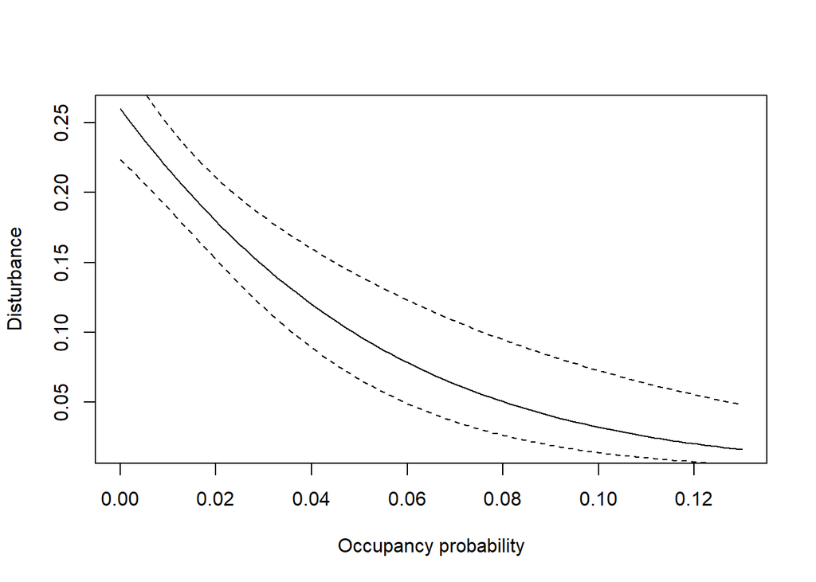

```r
# Plot Occupancy model
plot(x = Disturb_data$Dist_5km, y = Disturb_pred$mod.avg.pred, type = 'l',
     xlab = "Occupancy probability", ylab = "Disturbance" )
lines(x = Disturb_data$Dist_5km, y = Disturb_pred$lower.CL, lty = 2)
lines(x = Disturb_data$Dist_5km, y = Disturb_pred$upper.CL, lty = 2)
```

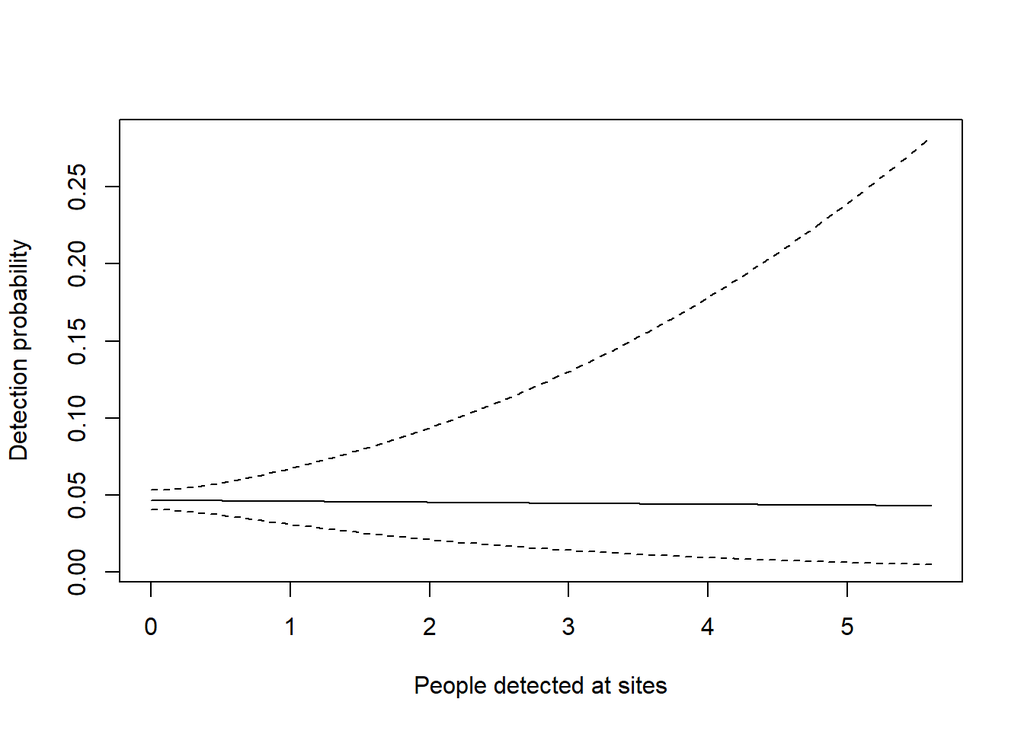

```r
# Plot Detection model
plot(x = People_data$People, y = People_pred$mod.avg.pred, type = 'l',
     xlab = "People detected at sites", ylab = "Detection probability", ylim = c(min(People_pred$lower.CL), max(People_pred$upper.CL)))
lines(x = People_data$People, y = People_pred$lower.CL, lty = 2)
lines(x = People_data$People, y = People_pred$upper.CL, lty = 2)
```